# R Project 2 SDS 322E

## Clustering Visualizations

We performed PAM clustering on the positionality of the soccer player’s, including whether they were a goalkeeper, defender, midfielder, or forward based on all the other attributes in the dataset. After initially running the algorithm we found that midfielders were hard to cluster because they have attributes of all players. The second time we ran the algorithm without the midfielders we found that the clusters were much easier to visualize.

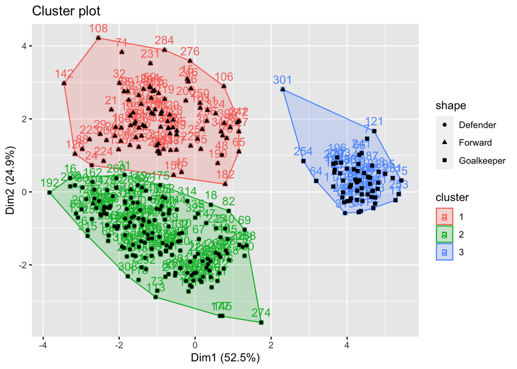

```r
small_soccer_no_mid <- small_soccer %>%
  filter(Position != 'Midfielder')
no_mid_pam <- small_soccer_no_mid %>%
  select_if(is.numeric)%>%
  scale()%>%
  pam(k=3)

cluster_column_pam <- small_soccer_no_mid %>%
  mutate(cluster = as.factor(no_mid_pam$clustering))
fviz_cluster(no_mid_pam, data=small_soccer_no_mid, shape = 0) +
  geom_point(aes(shape=small_soccer_no_mid$Position))+
  guides(shape = guide_legend(title = 'shape'))
```

```r
no_mid_pam$silinfo$avg.width
```

```
## [1] 0.3995679
```

```r
no_mid_pam$medoids
```

```
##        crossing  finishing  dribbling sprint_speed    stamina   strength
## [1,]  0.7434134  1.2784195  0.8737800    0.5864203  0.3141282 -0.2276156
## [2,]  0.6060721 -0.6421108  0.2826976    0.1971721  0.3740570  0.5541304
## [3,] -1.5913888 -1.3249661 -1.8088249   -1.4895704 -1.3039489 -0.6184887
##        aggression     vision    marking standing_tackle
## [1,] -0.003789619  1.1649092 -0.9981889      -0.7467162
## [2,]  0.466596785  0.4401255  1.0053424       0.8948196
## [3,] -1.258153361 -1.2729997 -1.3260394      -1.3063306
```